# KIRA PLASTINA

Snow

9/4/2021

# Define the problem

The implementation, of the K-Means clustering vs Hierarchical clustering should highlight the strengths and limitations of each approach in the context of the business. The findings should help inform the team in formulating the marketing and sales strategies of the brand. #Metric of success - Importing the data - Cleaning the data - performing a thorough EDA - Build K Means and Hierarchical model structures.

#Data relevance The dataset for this Independent project can be found here [http://bit.ly/EcommerceCustomersDataset].

- The dataset consists of 10 numerical and 8 categorical attributes. The ‘Revenue’ attribute can be used as the class label. “Administrative”, “Administrative Duration”, “Informational”, “Informational Duration”, “Product Related” and “Product Related Duration” represents the number of different types of pages visited by the visitor in that session and total time spent in each of these page categories. The values of these features are derived from the URL information of the pages visited by the user and updated in real-time when a user takes an action, e.g. moving from one page to another. -The “Bounce Rate”, “Exit Rate” and “Page Value” features represent the metrics measured by “Google Analytics” for each page in the e-commerce site. -The value of the “Bounce Rate” feature for a web page refers to the percentage of visitors who enter the site from that page and then leave (“bounce”) without triggering any other requests to the analytics server during that session. -The value of the “Exit Rate” feature for a specific web page is calculated as for all pageviews to the page, the percentage that was the last in the session. -The “Page Value” feature represents the average value for a web page that a user visited before completing an e-commerce transaction. -The “Special Day” feature indicates the closeness of the site visiting time to a specific special day (e.g. Mother’s Day, Valentine’s Day) in which the sessions are more likely to be finalized with the transaction. The value of this attribute is determined by considering the dynamics of e-commerce such as the duration between the order date and delivery date. For example, for Valentina’s day, this value takes a nonzero value between February 2 and February 12, zero before and after this date unless it is close to another special day, and its maximum value of 1 on February 8. -The dataset also includes the operating system, browser, region, traffic type, visitor type as returning or new visitor, a Boolean value indicating whether the date of the visit is weekend, and month of the year.

#Understanding the context

Kira Plastinina is a Russian brand that is sold through a defunct chain of retail stores in Russia, Ukraine, Kazakhstan, Belarus, China, Philippines, and Armenia. The brand’s Sales and Marketing team would like to understand their customer’s behavior from data that they have collected over the past year. More specifically, they would like to learn the characteristics of customer groups

#Experimental design

The experimental design will involve the following steps: Creating a Markdown which will comprise the following sections.

- Problem Definition
- Data Sourcing
- Check the Data
- Perform Data Cleaning
- Perform Exploratory Data Analysis (Univariate, Bivariate & Multivariate)
- Implement the Solution
- Challenge the Solution
- Follow up Questions

#Loading Data

```r
# Install packages needed
#install.packages("naniar")
#pkgs <- c("factoextra",  "NbClust")
#install.packages(pkgs)
#install.packages("superml")
```

```r
library (tidyr)
library(naniar)
library (ggplot2)
library (e1071)
library (corrplot)
library(factoextra)
library(NbClust)
library(superml)
df <- read.csv("online_shoppers_intention.csv")
```

```r
# Preview the data
head(df)
```

```
##   Administrative Administrative_Duration Informational Informational_Duration
## 1              0                       0             0                      0
## 2              0                       0             0                      0
## 3              0                      -1             0                     -1
## 4              0                       0             0                      0
## 5              0                       0             0                      0
## 6              0                       0             0                      0
##   ProductRelated ProductRelated_Duration BounceRates ExitRates PageValues
## 1              1                0.000000  0.20000000 0.2000000          0
## 2              2               64.000000  0.00000000 0.1000000          0
## 3              1               -1.000000  0.20000000 0.2000000          0
## 4              2                2.666667  0.05000000 0.1400000          0
## 5             10              627.500000  0.02000000 0.0500000          0
## 6             19              154.216667  0.01578947 0.0245614          0
##   SpecialDay Month OperatingSystems Browser Region TrafficType
## 1          0   Feb                1       1      1           1
## 2          0   Feb                2       2      1           2
## 3          0   Feb                4       1      9           3
## 4          0   Feb                3       2      2           4
## 5          0   Feb                3       3      1           4
## 6          0   Feb                2       2      1           3
##         VisitorType Weekend Revenue
## 1 Returning_Visitor   FALSE   FALSE
## 2 Returning_Visitor   FALSE   FALSE
## 3 Returning_Visitor   FALSE   FALSE
## 4 Returning_Visitor   FALSE   FALSE
## 5 Returning_Visitor    TRUE   FALSE
## 6 Returning_Visitor   FALSE   FALSE
```

```r
# Dimensionanity of the data
dim(df)
```

```
## [1] 12330    18
```

The dataframe has 12330 rows and 18 columns

#Data cleaning

```r
# first er will start by checking the column names.
colnames(df)
```

```
##  [1] "Administrative"          "Administrative_Duration"
##  [3] "Informational"           "Informational_Duration"
##  [5] "ProductRelated"          "ProductRelated_Duration"
##  [7] "BounceRates"             "ExitRates"
##  [9] "PageValues"              "SpecialDay"
## [11] "Month"                   "OperatingSystems"
## [13] "Browser"                 "Region"
## [15] "TrafficType"             "VisitorType"
## [17] "Weekend"                 "Revenue"
```

```r
# The column names have a mixture of uppercase and lowercase charachers we should correct that an d make all the characters lowercase.
names(df) <- tolower(names(df))

# Confrimation
colnames(df)
```

```
##  [1] "administrative"          "administrative_duration"
##  [3] "informational"           "informational_duration"
##  [5] "productrelated"          "productrelated_duration"
##  [7] "bouncerates"             "exitrates"
##  [9] "pagevalues"              "specialday"
## [11] "month"                   "operatingsystems"
## [13] "browser"                 "region"
## [15] "traffictype"             "visitortype"
## [17] "weekend"                 "revenue"
```

```r
# Let us find the datatypes of the data
str(df)
```

```
## 'data.frame':    12330 obs. of  18 variables:
##  $ administrative         : int  0 0 0 0 0 0 0 1 0 0 ...
##  $ administrative_duration: num  0 0 -1 0 0 0 -1 -1 0 0 ...
##  $ informational          : int  0 0 0 0 0 0 0 0 0 0 ...
##  $ informational_duration : num  0 0 -1 0 0 0 -1 -1 0 0 ...
##  $ productrelated         : int  1 2 1 2 10 19 1 1 2 3 ...
##  $ productrelated_duration: num  0 64 -1 2.67 627.5 ...
##  $ bouncerates            : num  0.2 0 0.2 0.05 0.02 ...
##  $ exitrates              : num  0.2 0.1 0.2 0.14 0.05 ...
##  $ pagevalues             : num  0 0 0 0 0 0 0 0 0 0 ...
##  $ specialday             : num  0 0 0 0 0 0 0.4 0 0.8 0.4 ...
##  $ month                  : chr  "Feb" "Feb" "Feb" "Feb" ...
##  $ operatingsystems       : int  1 2 4 3 3 2 2 1 2 2 ...
##  $ browser                : int  1 2 1 2 3 2 4 2 2 4 ...
##  $ region                 : int  1 1 9 2 1 1 3 1 2 1 ...
##  $ traffictype            : int  1 2 3 4 4 3 3 5 3 2 ...
##  $ visitortype            : chr  "Returning_Visitor" "Returning_Visitor" "Returning_Visitor" "Returning_Visitor" ...
##  $ weekend                : logi  FALSE FALSE FALSE FALSE TRUE FALSE ...
##  $ revenue                : logi  FALSE FALSE FALSE FALSE FALSE FALSE ...
```

There are a number of datatypes. Most of the data is in numerical format The Month and Visitor type columns are in character The weekend and revenue columns are have logical values We might need to encode the columns later in the model building phase

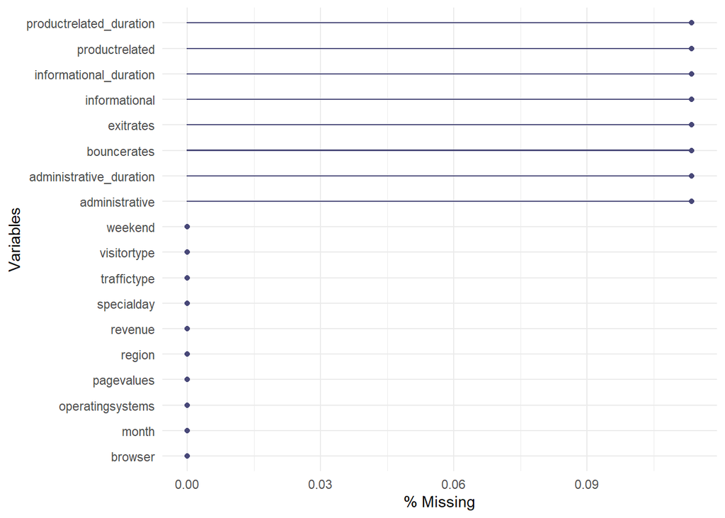

```r
# Lets check for missing Data
gg_miss_var(df, show_pct = TRUE)
```

There are several columns with missing values. They will affect the data analysis and will have to be dropped.

```r
# Dropping null values.
df <- na.omit(df) # Method 1 - Remove NA


# Confirming that the nulls have been removed

colSums(is.na(df))
```

```
##          administrative administrative_duration           informational
##                       0                       0                       0
##  informational_duration          productrelated productrelated_duration
##                       0                       0                       0
##             bouncerates               exitrates              pagevalues
##                       0                       0                       0
##              specialday                   month        operatingsystems
##                       0                       0                       0
##                 browser                  region             traffictype
##                       0                       0                       0
##             visitortype                 weekend                 revenue
##                       0                       0                       0
```

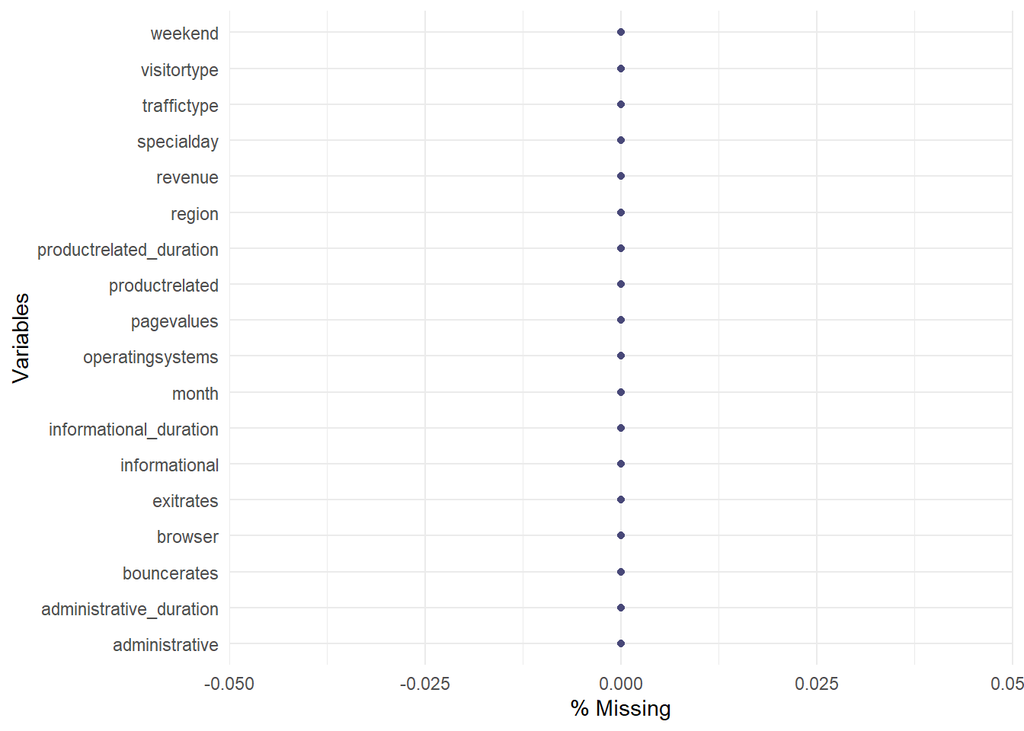

```r
gg_miss_var(df, show_pct = TRUE)
```

Now there are no more nulls in the dataframe.

Now lets check if there are duplicated records in the data.

```r
# Cheking for duplicates
df_dup <- df[duplicated(df),]
df_dup
```

```
##       administrative administrative_duration informational
## 159                0                       0             0
## 179                0                       0             0
## 419                0                       0             0
## 457                0                       0             0
## 484                0                       0             0
## 513                0                       0             0
## 555                0                       0             0
## 590                0                       0             0
## 660                0                       0             0
## 775                0                       0             0
## 873                0                       0             0
## 890                0                       0             0
## 923                0                       0             0
## 948                0                       0             0
```

[output cut: 457 more lines]

There are a number of duplicated records. The duplicated records sum up to 117 records.

```r
# Shape before
dim(df)
```

```
## [1] 12316    18
```

```r
# Removing duplicates
df <- unique(df)
# Shape after(confirmation)
dim (df)
```

```
## [1] 12199    18
```

We have removed the duplicates successfully

```r
str(df)
```

```
## 'data.frame':    12199 obs. of  18 variables:
##  $ administrative         : int  0 0 0 0 0 0 0 1 0 0 ...
##  $ administrative_duration: num  0 0 -1 0 0 0 -1 -1 0 0 ...
##  $ informational          : int  0 0 0 0 0 0 0 0 0 0 ...
##  $ informational_duration : num  0 0 -1 0 0 0 -1 -1 0 0 ...
##  $ productrelated         : int  1 2 1 2 10 19 1 1 2 3 ...
##  $ productrelated_duration: num  0 64 -1 2.67 627.5 ...
##  $ bouncerates            : num  0.2 0 0.2 0.05 0.02 ...
##  $ exitrates              : num  0.2 0.1 0.2 0.14 0.05 ...
##  $ pagevalues             : num  0 0 0 0 0 0 0 0 0 0 ...
##  $ specialday             : num  0 0 0 0 0 0 0.4 0 0.8 0.4 ...
##  $ month                  : chr  "Feb" "Feb" "Feb" "Feb" ...
##  $ operatingsystems       : int  1 2 4 3 3 2 2 1 2 2 ...
##  $ browser                : int  1 2 1 2 3 2 4 2 2 4 ...
##  $ region                 : int  1 1 9 2 1 1 3 1 2 1 ...
##  $ traffictype            : int  1 2 3 4 4 3 3 5 3 2 ...
##  $ visitortype            : chr  "Returning_Visitor" "Returning_Visitor" "Returning_Visitor" "Returning_Visitor" ...
##  $ weekend                : logi  FALSE FALSE FALSE FALSE TRUE FALSE ...
##  $ revenue                : logi  FALSE FALSE FALSE FALSE FALSE FALSE ...
##  - attr(*, "na.action")= 'omit' Named int [1:14] 1066 1133 1134 1135 1136 1137 1474 1475 1476 1477 ...
##   ..- attr(*, "names")= chr [1:14] "1066" "1133" "1134" "1135" ...
```

## Outlier detection and Handling

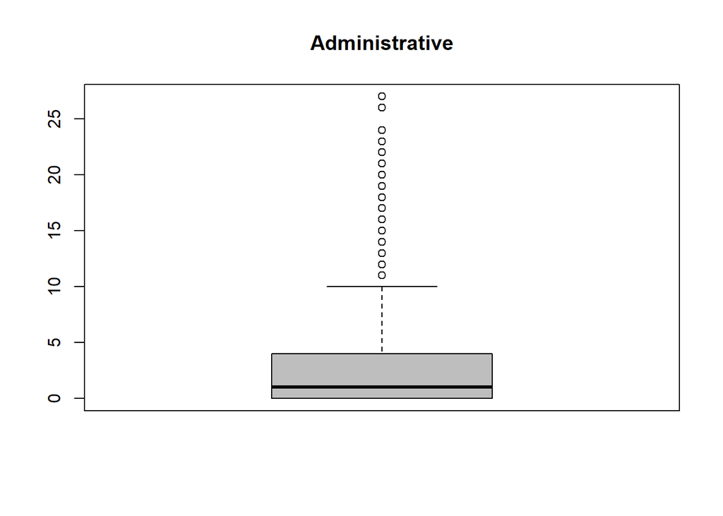

```r
# Plotting boxplots to check for outliers

boxplot(df$administrative,col='grey', main = 'Administrative')
```

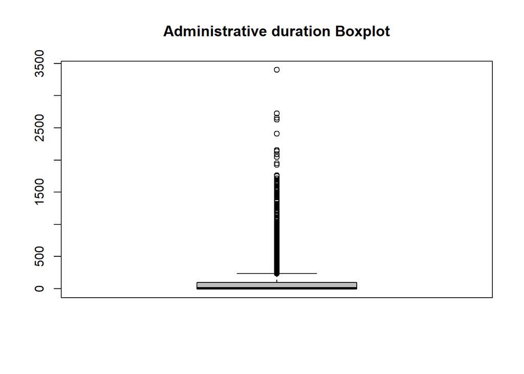

```r
boxplot(df$administrative_duration,col='grey', main = 'Administrative duration Boxplot')
```

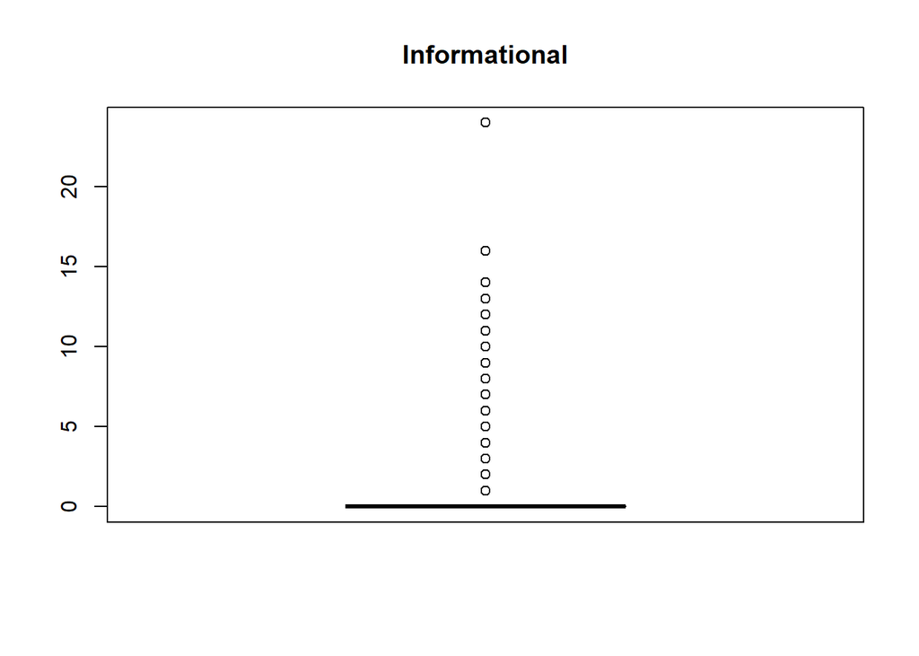

```r
boxplot(df$informational,col='grey', main = 'Informational')
```

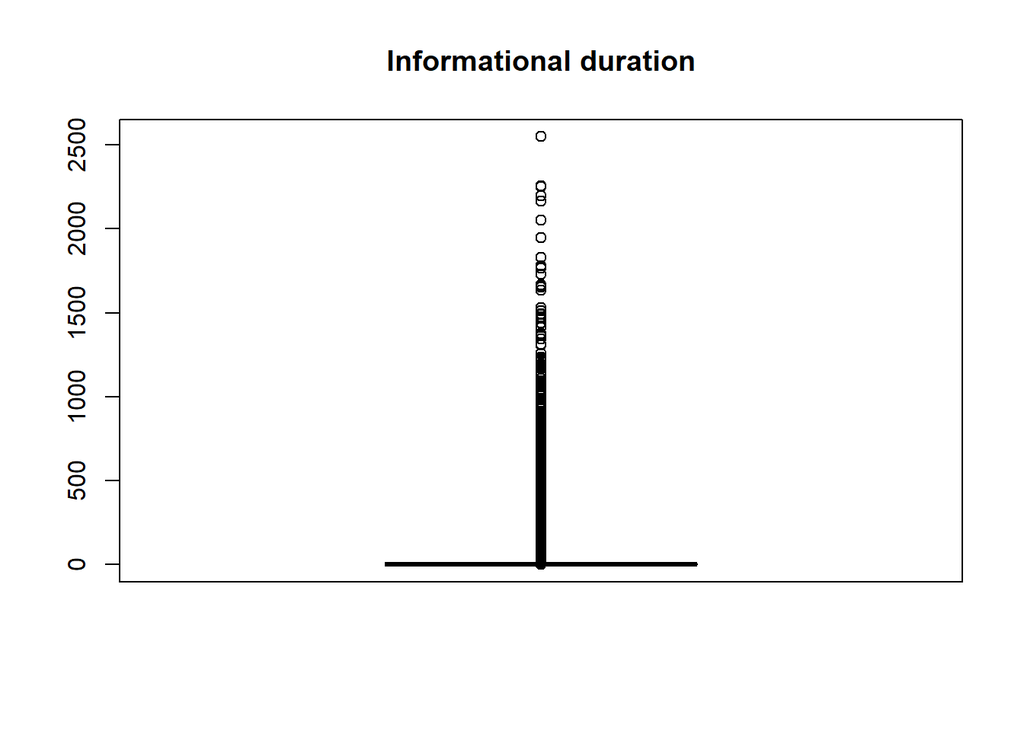

```r
boxplot(df$informational_duration,col='grey', main = 'Informational duration')
```

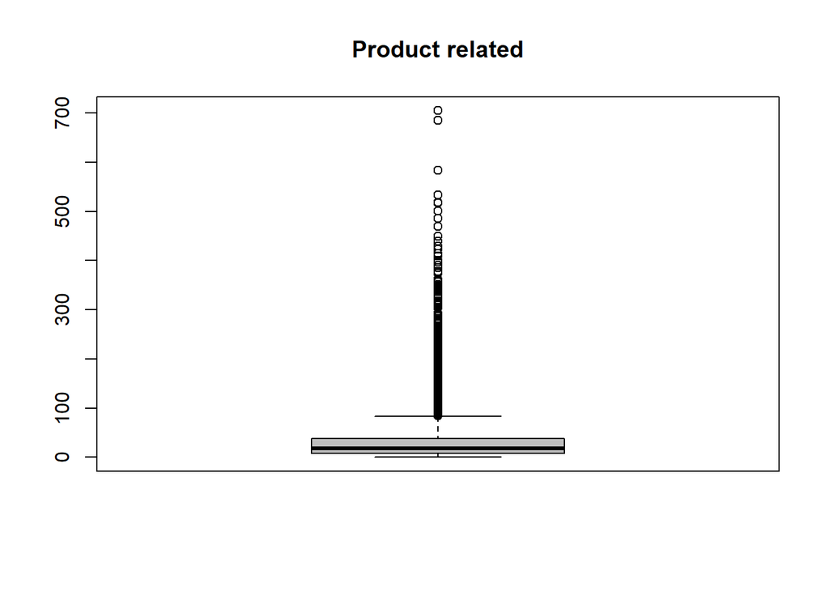

```r
boxplot(df$productrelated,col='grey', main = 'Product related')
```

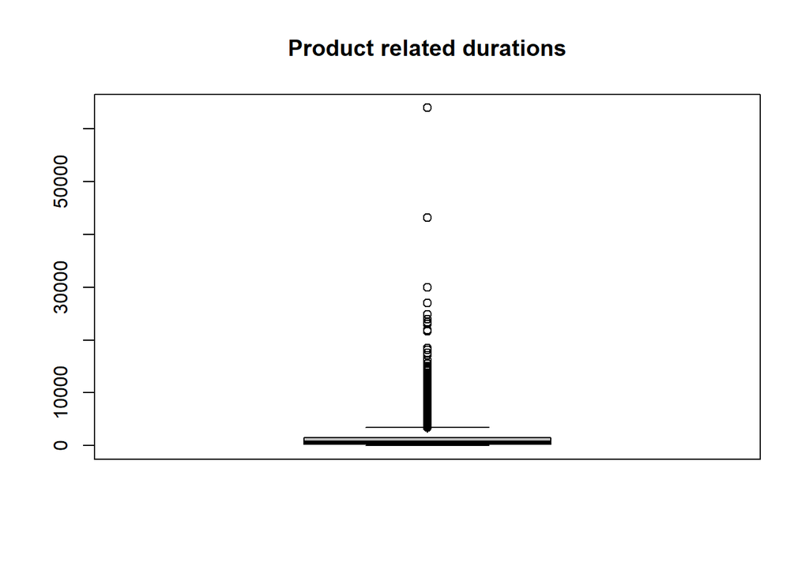

```r
boxplot(df$productrelated_duration,col='grey', main = 'Product related durations')
```

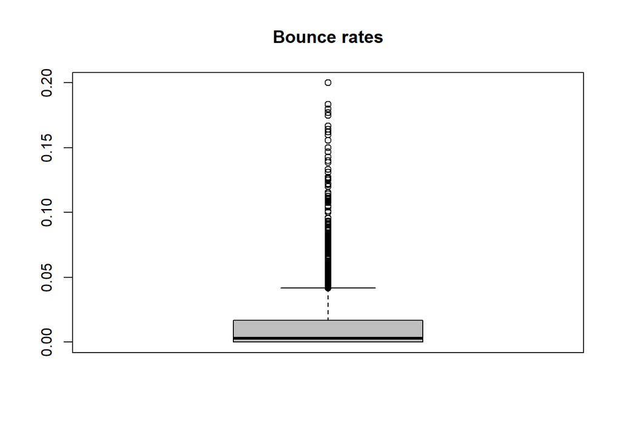

```r
boxplot(df$bouncerates,col='grey', main = 'Bounce rates')
```

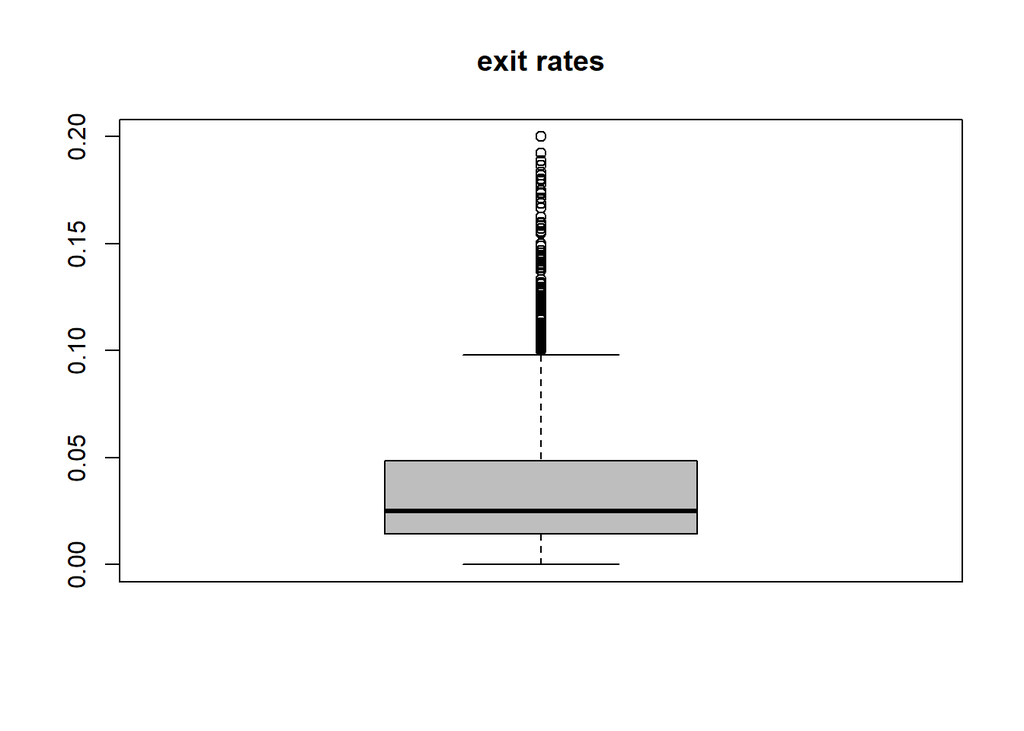

```r
boxplot(df$exitrates,col='grey', main = 'exit rates')
```

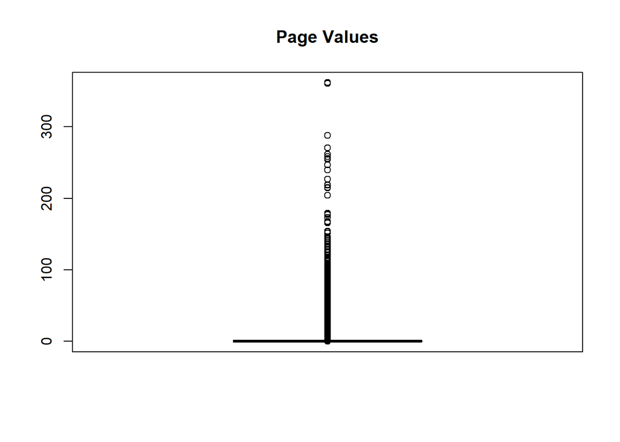

```r
boxplot(df$pagevalues,col='grey', main = 'Page Values')
```

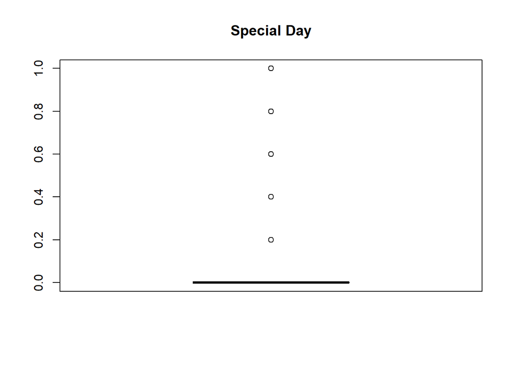

```r
boxplot(df$specialday,col='grey', main = 'Special Day')
```

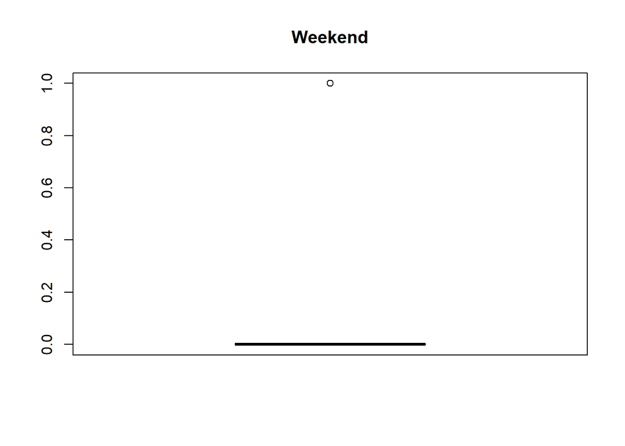

```r
boxplot(df$weekend, col='grey', main = 'Weekend')
```

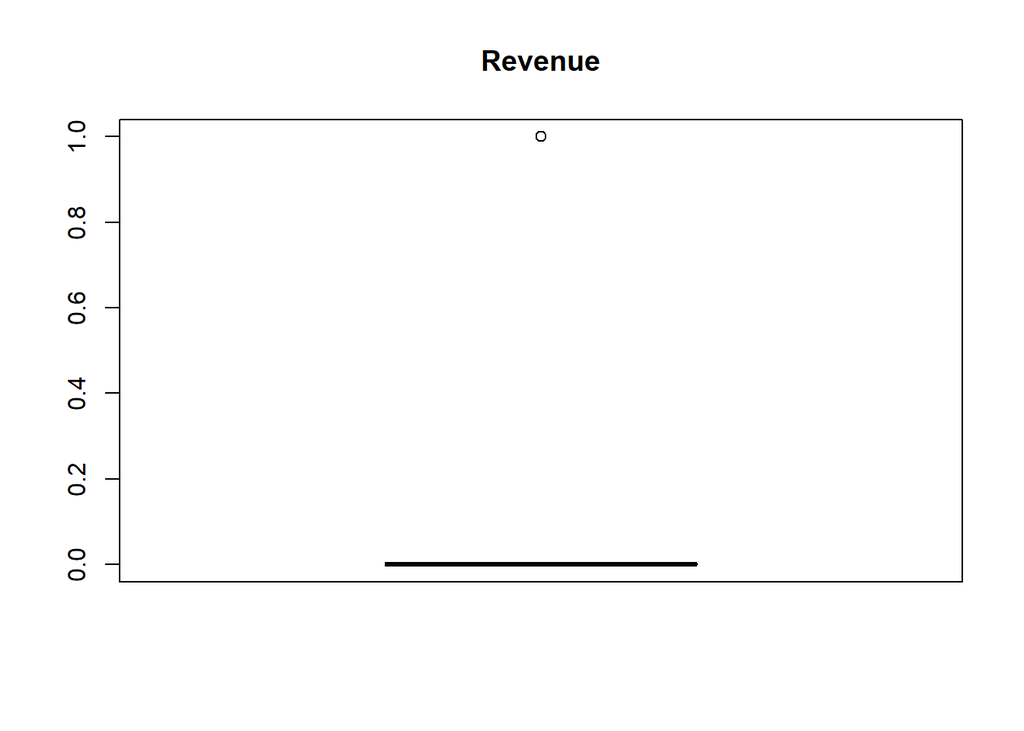

```r
boxplot(df$revenue,col='grey', main = 'Revenue')
```

From the boxplots we can see that all the columns have too many outliers to remove.

```r
summary (df)
```

```
##  administrative  administrative_duration informational
##  Min.   : 0.00   Min.   :  -1.00         Min.   : 0.0000
##  1st Qu.: 0.00   1st Qu.:   0.00         1st Qu.: 0.0000
##  Median : 1.00   Median :   9.00         Median : 0.0000
##  Mean   : 2.34   Mean   :  81.68         Mean   : 0.5088
##  3rd Qu.: 4.00   3rd Qu.:  94.75         3rd Qu.: 0.0000
##  Max.   :27.00   Max.   :3398.75         Max.   :24.0000
##  informational_duration productrelated   productrelated_duration
##  Min.   :  -1.00        Min.   :  0.00   Min.   :   -1.0
##  1st Qu.:   0.00        1st Qu.:  8.00   1st Qu.:  193.6
##  Median :   0.00        Median : 18.00   Median :  609.5
##  Mean   :  34.84        Mean   : 32.06   Mean   : 1207.5
##  3rd Qu.:   0.00        3rd Qu.: 38.00   3rd Qu.: 1477.6
##  Max.   :2549.38        Max.   :705.00   Max.   :63973.5
##   bouncerates        exitrates         pagevalues        specialday
##  Min.   :0.00000   Min.   :0.00000   Min.   :  0.000   Min.   :0.00000
##  1st Qu.:0.00000   1st Qu.:0.01422   1st Qu.:  0.000   1st Qu.:0.00000
##  Median :0.00293   Median :0.02500   Median :  0.000   Median :0.00000
##  Mean   :0.02045   Mean   :0.04150   Mean   :  5.952   Mean   :0.06197
##  3rd Qu.:0.01667   3rd Qu.:0.04848   3rd Qu.:  0.000   3rd Qu.:0.00000
##  Max.   :0.20000   Max.   :0.20000   Max.   :361.764   Max.   :1.00000
##     month           operatingsystems    browser           region
##  Length:12199       Min.   :1.000    Min.   : 1.000   Min.   :1.000
##  Class :character   1st Qu.:2.000    1st Qu.: 2.000   1st Qu.:1.000
##  Mode  :character   Median :2.000    Median : 2.000   Median :3.000
##                     Mean   :2.124    Mean   : 2.358   Mean   :3.153
##                     3rd Qu.:3.000    3rd Qu.: 2.000   3rd Qu.:4.000
##                     Max.   :8.000    Max.   :13.000   Max.   :9.000
##   traffictype     visitortype         weekend         revenue
##  Min.   : 1.000   Length:12199       Mode :logical   Mode :logical
##  1st Qu.: 2.000   Class :character   FALSE:9343      FALSE:10291
##  Median : 2.000   Mode  :character   TRUE :2856      TRUE :1908
##  Mean   : 4.075
##  3rd Qu.: 4.000
##  Max.   :20.000
```

```r
paste("The variance for Administrative Duration is" , (var(df$administrative_duration)), sep = " ")
```

```
## [1] "The variance for Administrative Duration is 31516.2503598087"
```

```r
paste("The variance for Informational Duration is" , (var(df$informational_duration)), sep = " ")
```

```
## [1] "The variance for Informational Duration is 20010.5068641882"
```

```r
paste("The variance for Product Related  is" , (var(df$productrelated)), sep = " ")
```

```
## [1] "The variance for Product Related  is 1989.24129586768"
```

```r
paste("The variance for Product Related Duration is" , (var(df$productrelated_duration  )), sep = " ")
```

```
## [1] "The variance for Product Related Duration is 3686121.49674345"
```

```r
paste("The variance for Bounce Rates  is" , (var(df$bouncerates)), sep = " ")
```

```
## [1] "The variance for Bounce Rates  is 0.0020613872549165"
```

```r
paste("The variance for Exit rates is" , (var(df$exitrates)), sep = " ")
```

```
## [1] "The variance for Exit rates is 0.00213879984993362"
```

```r
paste("The variance for Page Values is" , (var(df$pagevalues)), sep = " ")
```

```
## [1] "The variance for Page Values is 348.113183761479"
```

```r
paste("The variance for Special day  is" , (var(df$specialday)), sep = " ")
```

```
## [1] "The variance for Special day  is 0.0398843209243294"
```

```r
paste("The variance for Operating System  is" , (var(df$operatingsystems)), sep = " ")
```

```
## [1] "The variance for Operating System  is 0.822622912882059"
```

```r
paste("The variance for Browser is" , (var(df$browser)), sep = " ")
```

```
## [1] "The variance for Browser is 2.92607545357061"
```

```r
paste("The variance for Region  is" , (var(df$region)), sep = " ")
```

```
## [1] "The variance for Region  is 5.77171219512844"
```

```r
paste("The variance for Traffic type is" , (var(df$traffictype)), sep = " ")
```

```
## [1] "The variance for Traffic type is 16.1267517123029"
```

The standard deviation

```r
paste("The Standard Deviation for Administrative Duration is" , (sd(df$administrative_duration)), sep = " ")
```

```
## [1] "The Standard Deviation for Administrative Duration is 177.528167792632"
```

```r
paste("The Standard Deviation for Informational Duration is" , (sd(df$informational_duration)), sep = " ")
```

```
## [1] "The Standard Deviation for Informational Duration is 141.458498734393"
```

```r
paste("The Standard Deviation for Product Related  is" , (sd(df$productrelated)), sep = " ")
```

```
## [1] "The Standard Deviation for Product Related  is 44.6009113793394"
```

```r
paste("The Standard Deviation for Product Related Duration is" , (sd(df$productrelated_duration  )), sep = " ")
```

```
## [1] "The Standard Deviation for Product Related Duration is 1919.92747174039"
```

```r
paste("The Standard Deviation for Bounce Rates  is" , (sd(df$bouncerates)), sep = " ")
```

```
## [1] "The Standard Deviation for Bounce Rates  is 0.0454025027384669"
```

```r
paste("The Standard Deviation for Exit rates is" , (sd(df$exitrates)), sep = " ")
```

```
## [1] "The Standard Deviation for Exit rates is 0.046247160452655"
```

```r
paste("The Standard Deviation for Page Values is" , (sd(df$pagevalues)), sep = " ")
```

```
## [1] "The Standard Deviation for Page Values is 18.6577915027872"
```

```r
paste("The Standard Deviation for Special day  is" , (sd(df$specialday)), sep = " ")
```

```
## [1] "The Standard Deviation for Special day  is 0.199710592919678"
```

```r
paste("The Standard Deviation for Operating System  is" , (sd(df$operatingsystems)), sep = " ")
```

```
## [1] "The Standard Deviation for Operating System  is 0.906985618894842"
```

```r
paste("The Standard Deviation for Browser is" , (sd(df$browser)), sep = " ")
```

```
## [1] "The Standard Deviation for Browser is 1.71057752047974"
```

```r
paste("The Standard Deviation for Region  is" , (sd(df$region)), sep = " ")
```

```
## [1] "The Standard Deviation for Region  is 2.40243880153656"
```

```r
paste("The Standard Deviation for Traffic type is" , (sd(df$traffictype)), sep = " ")
```

```
## [1] "The Standard Deviation for Traffic type is 4.01581270881785"
```

The Kurtosis

```r
paste("The kurtosis for Administrative Duration is" , (kurtosis(df$administrative_duration)), sep = " ")
```

```
## [1] "The kurtosis for Administrative Duration is 50.085181158405"
```

```r
paste("The kurtosis for Informational Duration is" , (kurtosis(df$informational_duration)), sep = " ")
```

```
## [1] "The kurtosis for Informational Duration is 75.4512246461555"
```

```r
paste("The kurtosis for Product Related  is" , (kurtosis(df$productrelated)), sep = " ")
```

```
## [1] "The kurtosis for Product Related  is 31.0434452164828"
```

```r
paste("The kurtosis for Product Related Duration is" , (kurtosis(df$productrelated_duration  )), sep = " ")
```

```
## [1] "The kurtosis for Product Related Duration is 136.56790690015"
```

```r
paste("The kurtosis for Bounce Rates  is" , (kurtosis(df$bouncerates)), sep = " ")
```

```
## [1] "The kurtosis for Bounce Rates  is 9.25305503204776"
```

```r
paste("The kurtosis for Exit rates is" , (kurtosis(df$exitrates)), sep = " ")
```

```
## [1] "The kurtosis for Exit rates is 4.62300253695039"
```

```r
paste("The kurtosis for Page Values is" , (kurtosis(df$pagevalues)), sep = " ")
```

```
## [1] "The kurtosis for Page Values is 64.9291691002094"
```

```r
paste("The kurtosis for Special day  is" , (kurtosis(df$specialday)), sep = " ")
```

```
## [1] "The kurtosis for Special day  is 9.78395765970814"
```

```r
paste("The kurtosis for Operating System  is" , (kurtosis(df$operatingsystems)), sep = " ")
```

```
## [1] "The kurtosis for Operating System  is 10.266692831375"
```

```r
paste("The kurtosis for Browser is" , (kurtosis(df$browser)), sep = " ")
```

```
## [1] "The kurtosis for Browser is 12.534043219127"
```

```r
paste("The kurtosis for Region  is" , (kurtosis(df$region)), sep = " ")
```

```
## [1] "The kurtosis for Region  is -0.160270347887721"
```

```r
paste("The kurtosis for Traffic type is" , (kurtosis(df$traffictype)), sep = " ")
```

```
## [1] "The kurtosis for Traffic type is 3.46506739912327"
```

this is to see the number of people that added revenue.

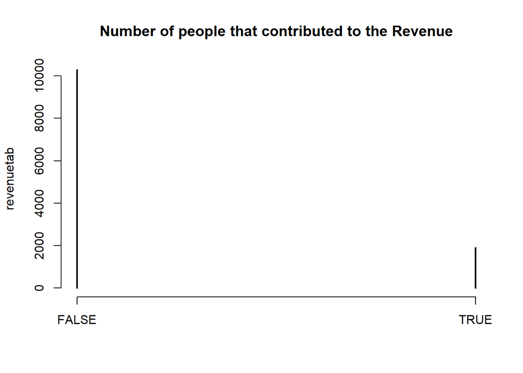

```r
revenuetab <- table(df$revenue)
plot(revenuetab, main = "Number of people that contributed to the Revenue")
```

Histograms of the different columns

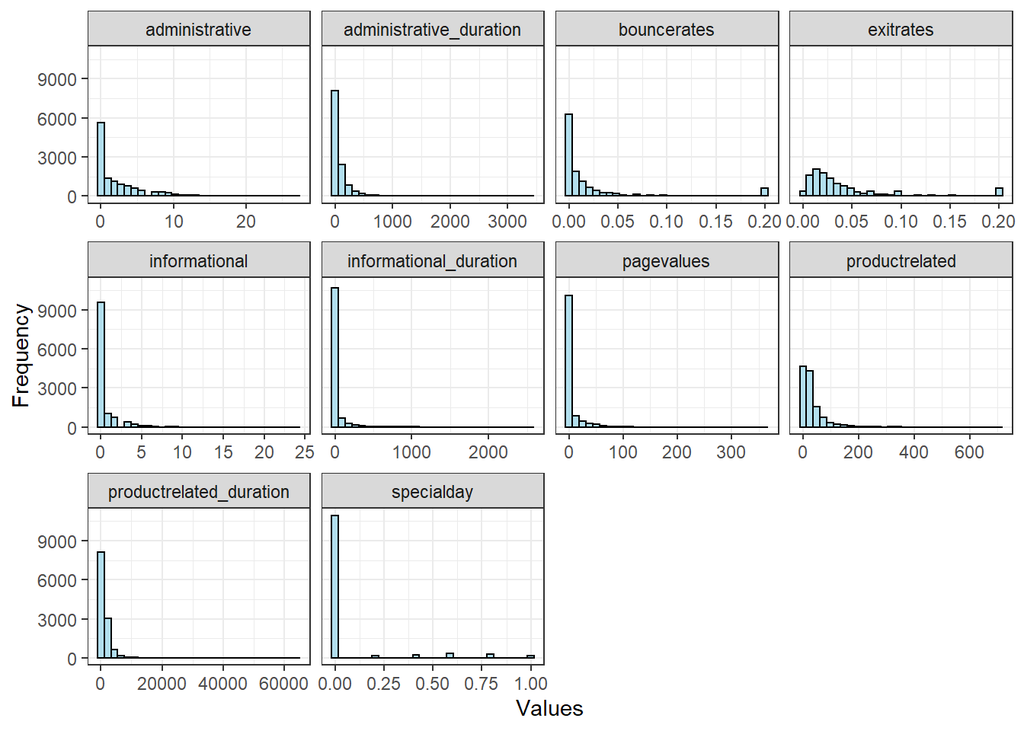

```r
df %>%
  gather(attributes, value, 1:10) %>%
  ggplot(aes(x = value)) +
  geom_histogram(fill = 'lightblue2', color = 'black') +
  facet_wrap(~attributes, scales = 'free_x') +
  labs(x="Values", y="Frequency") +
  theme_bw()
```

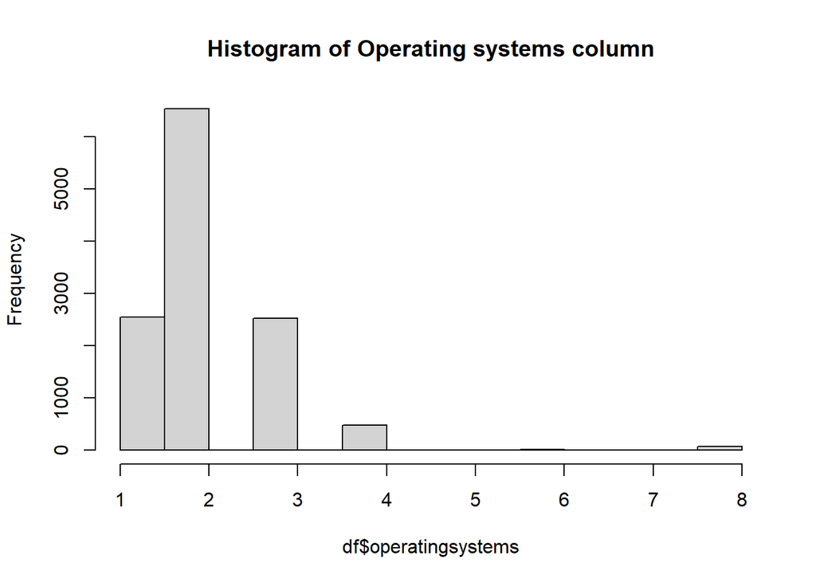

```r
hist(df$operatingsystems, main = 'Histogram of Operating systems column')
```

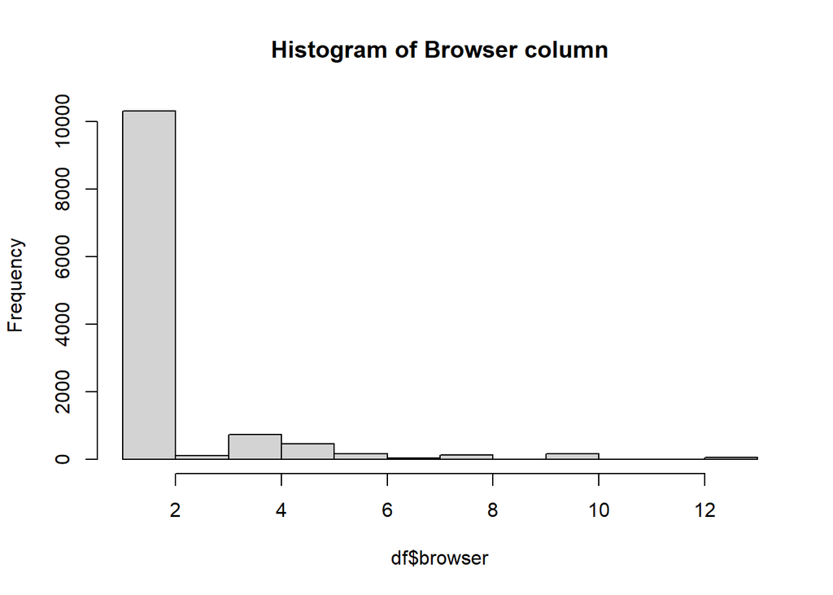

```r
hist(df$browser, main = 'Histogram of Browser column')
```

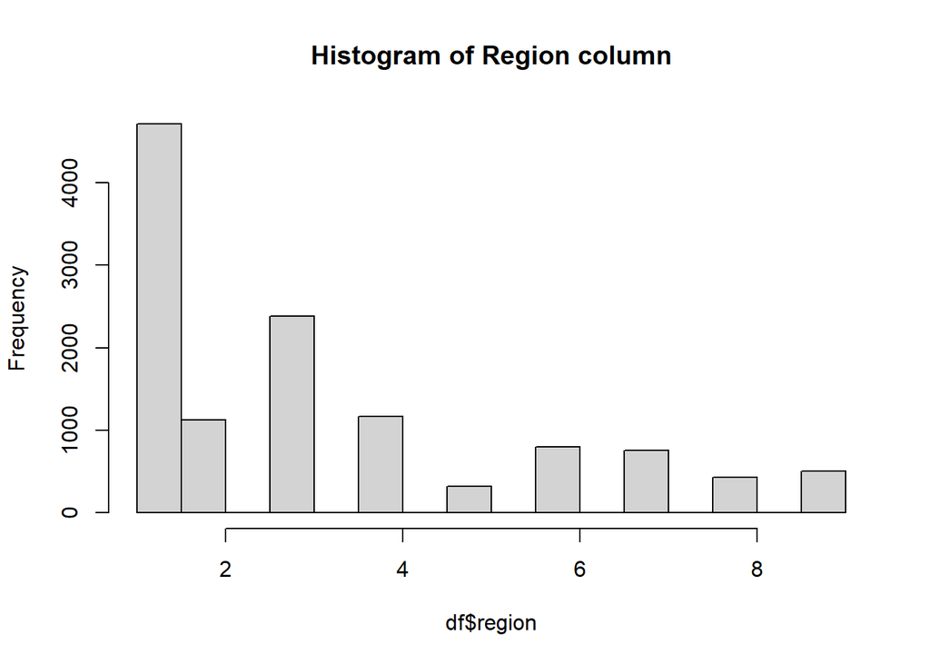

```r
hist(df$region, main = 'Histogram of Region column')
```

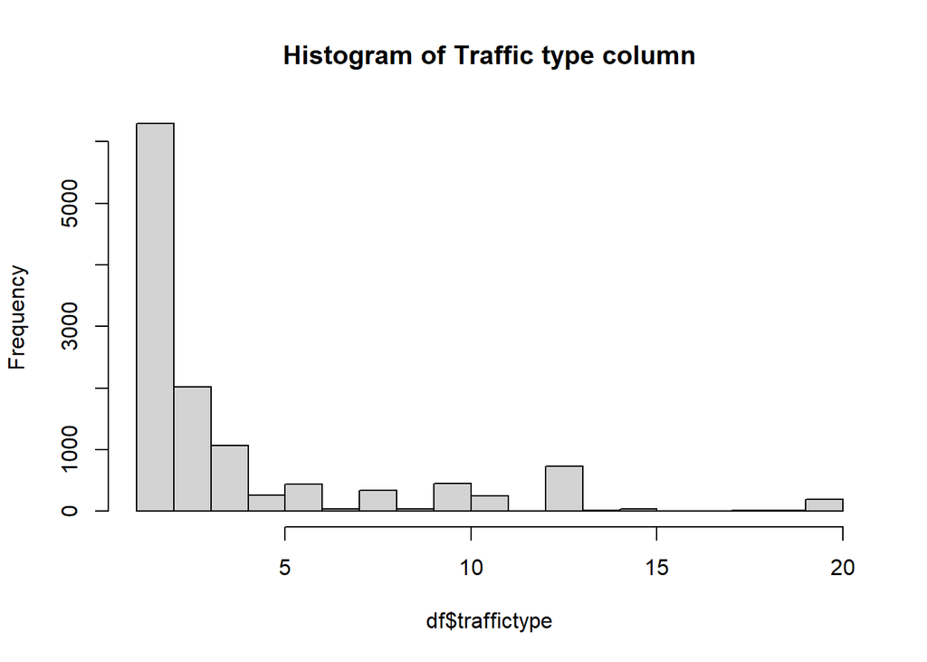

```r
hist(df$traffictype, main = 'Histogram of Traffic type column')
```

#Bivariate Analysis ## Numerical columns

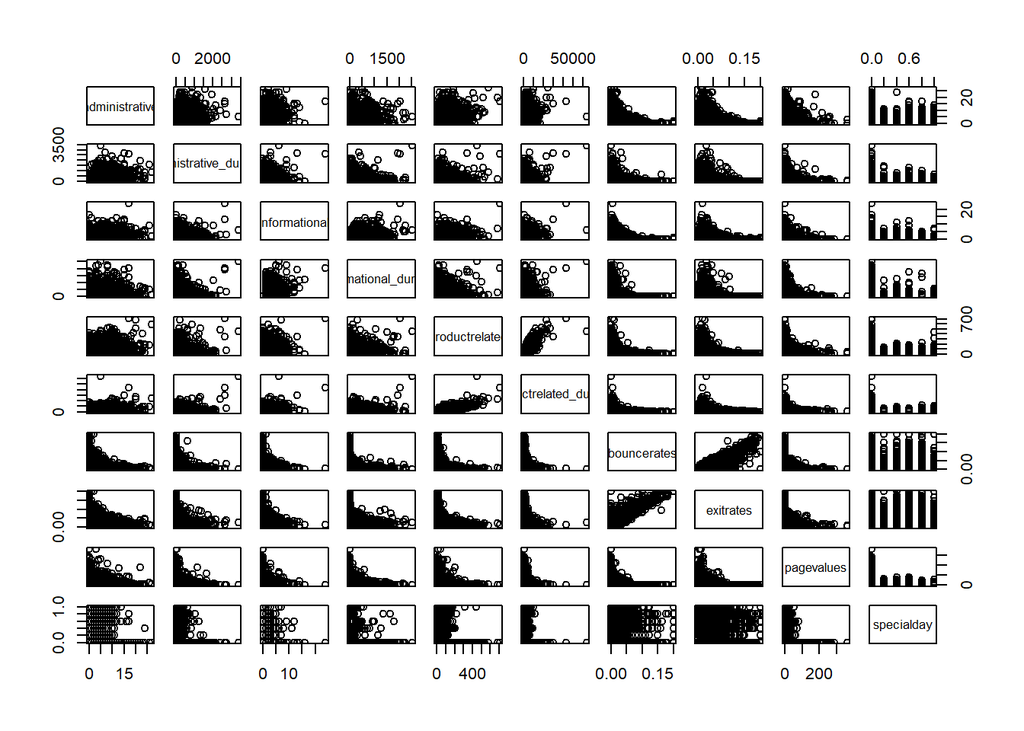

```r
# The following is a pair plot of all the number variables

pairs(df[,1:10])
```

We should find the correlation of the data

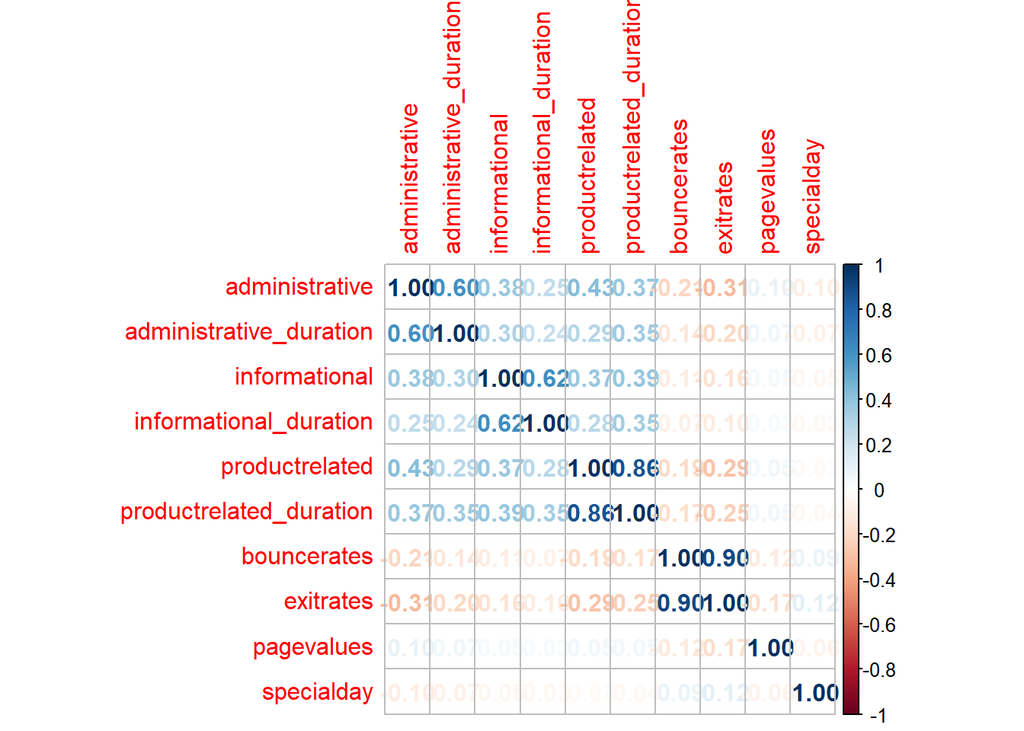

```r
# calculate correlations
correlations <- cor(df[,1:10])
# create correlation plot
corrplot(correlations, method="number")
```

From the correlation plot that there are only few columns that are correlated. The correlations is usually from the duration columns. However, the bounce rate and exit rates are also correlated

# categorical columns

Lets look at the months which have a lot of customers. and the type of customers.

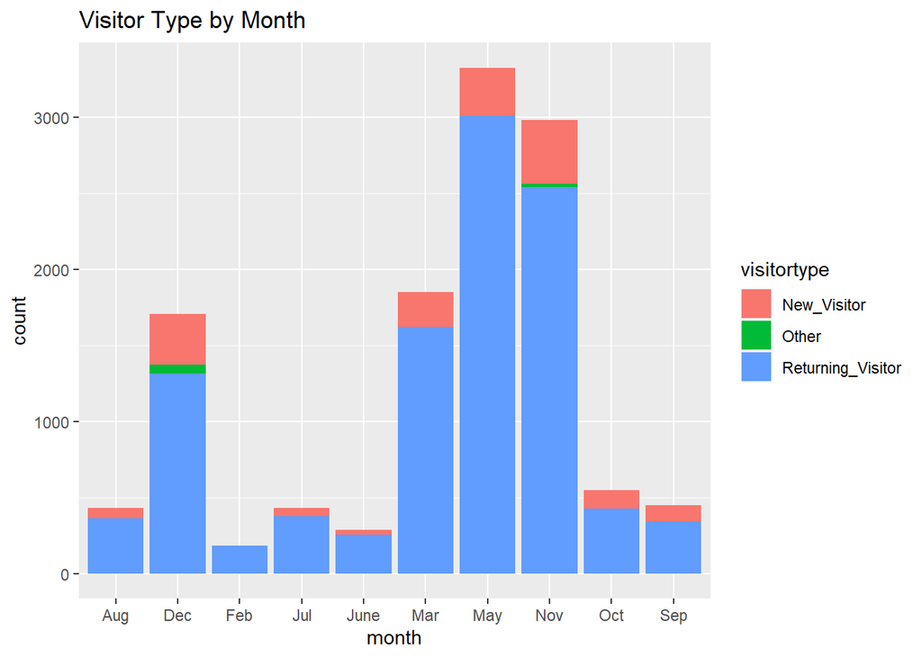

```r
# Visitor Type vs Month
df %>%
    ggplot(aes(month)) +
    geom_bar(aes(fill = visitortype))+
    labs(title = "Visitor Type by Month")
```

It can be observed that the months with the most number of customers are: May, November, March and December. This can be as a result of the various celebrations in these months. For instance, in march, most people are usually shopping foe Easter products. In November, the black Friday sales generate a lot of traffic for the site. They are also shopping for Thanksgiving, Christmas and Hanukkah. It is also clear that the site gets a lot of returning visitors. New visitors are usually found in the months that there is an increase in customer traffic.

```r
str(df

    )
```

```
## 'data.frame':    12199 obs. of  18 variables:
##  $ administrative         : int  0 0 0 0 0 0 0 1 0 0 ...
##  $ administrative_duration: num  0 0 -1 0 0 0 -1 -1 0 0 ...
##  $ informational          : int  0 0 0 0 0 0 0 0 0 0 ...
##  $ informational_duration : num  0 0 -1 0 0 0 -1 -1 0 0 ...
##  $ productrelated         : int  1 2 1 2 10 19 1 1 2 3 ...
##  $ productrelated_duration: num  0 64 -1 2.67 627.5 ...
##  $ bouncerates            : num  0.2 0 0.2 0.05 0.02 ...
##  $ exitrates              : num  0.2 0.1 0.2 0.14 0.05 ...
##  $ pagevalues             : num  0 0 0 0 0 0 0 0 0 0 ...
##  $ specialday             : num  0 0 0 0 0 0 0.4 0 0.8 0.4 ...
##  $ month                  : chr  "Feb" "Feb" "Feb" "Feb" ...
##  $ operatingsystems       : int  1 2 4 3 3 2 2 1 2 2 ...
##  $ browser                : int  1 2 1 2 3 2 4 2 2 4 ...
##  $ region                 : int  1 1 9 2 1 1 3 1 2 1 ...
##  $ traffictype            : int  1 2 3 4 4 3 3 5 3 2 ...
##  $ visitortype            : chr  "Returning_Visitor" "Returning_Visitor" "Returning_Visitor" "Returning_Visitor" ...
##  $ weekend                : logi  FALSE FALSE FALSE FALSE TRUE FALSE ...
##  $ revenue                : logi  FALSE FALSE FALSE FALSE FALSE FALSE ...
##  - attr(*, "na.action")= 'omit' Named int [1:14] 1066 1133 1134 1135 1136 1137 1474 1475 1476 1477 ...
##   ..- attr(*, "names")= chr [1:14] "1066" "1133" "1134" "1135" ...
```

Preparation of the data for K-means and Hierarchical modelling first its label encoding

```r
lbl <- LabelEncoder$new()
lbl$fit(df$month)
df$month <- lbl$fit_transform(df$month)
lbl$fit(df$visitortype)
df$visitortype <- lbl$fit_transform(df$visitortype)


head(df)
```

```
##   administrative administrative_duration informational informational_duration
## 1              0                       0             0                      0
## 2              0                       0             0                      0
## 3              0                      -1             0                     -1
## 4              0                       0             0                      0
## 5              0                       0             0                      0
## 6              0                       0             0                      0
##   productrelated productrelated_duration bouncerates exitrates pagevalues
## 1              1                0.000000  0.20000000 0.2000000          0
## 2              2               64.000000  0.00000000 0.1000000          0
## 3              1               -1.000000  0.20000000 0.2000000          0
## 4              2                2.666667  0.05000000 0.1400000          0
## 5             10              627.500000  0.02000000 0.0500000          0
## 6             19              154.216667  0.01578947 0.0245614          0
##   specialday month operatingsystems browser region traffictype visitortype
## 1          0     0                1       1      1           1           0
## 2          0     0                2       2      1           2           0
## 3          0     0                4       1      9           3           0
## 4          0     0                3       2      2           4           0
## 5          0     0                3       3      1           4           0
## 6          0     0                2       2      1           3           0
##   weekend revenue
## 1   FALSE   FALSE
## 2   FALSE   FALSE
## 3   FALSE   FALSE
## 4   FALSE   FALSE
## 5    TRUE   FALSE
## 6   FALSE   FALSE
```

Scaling the data frame.

```r
dfscaled <- as.data.frame(scale(df))
head(dfscaled)
```

```
##   administrative administrative_duration informational informational_duration
## 1     -0.7025315              -0.4601081    -0.3988128             -0.2462725
## 2     -0.7025315              -0.4601081    -0.3988128             -0.2462725
## 3     -0.7025315              -0.4657410    -0.3988128             -0.2533417
## 4     -0.7025315              -0.4601081    -0.3988128             -0.2462725
## 5     -0.7025315              -0.4601081    -0.3988128             -0.2462725
## 6     -0.7025315              -0.4601081    -0.3988128             -0.2462725
##   productrelated productrelated_duration  bouncerates  exitrates pagevalues
## 1     -0.6963635              -0.6289343  3.954699721  3.4273070 -0.3190356
## 2     -0.6739424              -0.5955997 -0.450343788  1.2650121 -0.3190356
## 3     -0.6963635              -0.6294551  3.954699721  3.4273070 -0.3190356
## 4     -0.6739424              -0.6275453  0.650917089  2.1299300 -0.3190356
## 5     -0.4945739              -0.3020990 -0.009839437  0.1838646 -0.3190356
## 6     -0.2927843              -0.5486101 -0.102577188 -0.3661929 -0.3190356
##   specialday     month operatingsystems    browser     region traffictype
## 1 -0.3103105 -1.538019       -1.2396607 -0.7939682 -0.8962939 -0.76562243
## 2 -0.3103105 -1.538019       -0.1371074 -0.2093703 -0.8962939 -0.51660683
## 3 -0.3103105 -1.538019        2.0679992 -0.7939682  2.4336556 -0.26759123
## 4 -0.3103105 -1.538019        0.9654459 -0.2093703 -0.4800502 -0.01857564
## 5 -0.3103105 -1.538019        0.9654459  0.3752276 -0.8962939 -0.01857564
## 6 -0.3103105 -1.538019       -0.1371074 -0.2093703 -0.8962939 -0.26759123
##   visitortype    weekend    revenue
## 1  -0.4032028 -0.5528638 -0.4305688
## 2  -0.4032028 -0.5528638 -0.4305688
## 3  -0.4032028 -0.5528638 -0.4305688
## 4  -0.4032028 -0.5528638 -0.4305688
## 5  -0.4032028  1.8086156 -0.4305688
## 6  -0.4032028 -0.5528638 -0.4305688
```

```r
summary(dfscaled)
```

```
##  administrative    administrative_duration informational
##  Min.   :-0.7025   Min.   :-0.46574        Min.   :-0.3988
##  1st Qu.:-0.7025   1st Qu.:-0.46011        1st Qu.:-0.3988
##  Median :-0.4023   Median :-0.40941        Median :-0.3988
##  Mean   : 0.0000   Mean   : 0.00000        Mean   : 0.0000
##  3rd Qu.: 0.4984   3rd Qu.: 0.07361        3rd Qu.:-0.3988
##  Max.   : 7.4035   Max.   :18.68474        Max.   :18.4127
##  informational_duration productrelated    productrelated_duration
##  Min.   :-0.2533        Min.   :-0.7188   Min.   :-0.6295
##  1st Qu.:-0.2463        1st Qu.:-0.5394   1st Qu.:-0.5281
##  Median :-0.2463        Median :-0.3152   Median :-0.3115
##  Mean   : 0.0000        Mean   : 0.0000   Mean   : 0.0000
##  3rd Qu.:-0.2463        3rd Qu.: 0.1332   3rd Qu.: 0.1407
##  Max.   :17.7758        Max.   :15.0881   Max.   :32.6919
##   bouncerates         exitrates         pagevalues       specialday
##  Min.   :-0.45034   Min.   :-0.8973   Min.   :-0.319   Min.   :-0.3103
##  1st Qu.:-0.45034   1st Qu.:-0.5897   1st Qu.:-0.319   1st Qu.:-0.3103
##  Median :-0.38580   Median :-0.3567   Median :-0.319   Median :-0.3103
##  Mean   : 0.00000   Mean   : 0.0000   Mean   : 0.000   Mean   : 0.0000
##  3rd Qu.:-0.08326   3rd Qu.: 0.1511   3rd Qu.:-0.319   3rd Qu.:-0.3103
##  Max.   : 3.95470   Max.   : 3.4273   Max.   :19.070   Max.   : 4.6969
##      month         operatingsystems     browser            region
##  Min.   :-1.5380   Min.   :-1.2397   Min.   :-0.7940   Min.   :-0.89629
##  1st Qu.:-0.8664   1st Qu.:-0.1371   1st Qu.:-0.2094   1st Qu.:-0.89629
##  Median :-0.1948   Median :-0.1371   Median :-0.2094   Median :-0.06381
##  Mean   : 0.0000   Mean   : 0.0000   Mean   : 0.0000   Mean   : 0.00000
##  3rd Qu.: 0.8126   3rd Qu.: 0.9654   3rd Qu.:-0.2094   3rd Qu.: 0.35244
##  Max.   : 1.4842   Max.   : 6.4782   Max.   : 6.2212   Max.   : 2.43366
##   traffictype        visitortype         weekend           revenue
##  Min.   :-0.76562   Min.   :-0.4032   Min.   :-0.5529   Min.   :-0.4306
##  1st Qu.:-0.51661   1st Qu.:-0.4032   1st Qu.:-0.5529   1st Qu.:-0.4306
##  Median :-0.51661   Median :-0.4032   Median :-0.5529   Median :-0.4306
##  Mean   : 0.00000   Mean   : 0.0000   Mean   : 0.0000   Mean   : 0.0000
##  3rd Qu.:-0.01858   3rd Qu.:-0.4032   3rd Qu.:-0.5529   3rd Qu.:-0.4306
##  Max.   : 3.96567   Max.   : 4.8999   Max.   : 1.8086   Max.   : 2.3223
```

Now we can normalize the data.

```r
df_norm <- as.data.frame(apply(dfscaled, 2, function(x) (x - min(x))/(max(x)-min(x))))
```

```r
summary(df_norm)
```

```
##  administrative    administrative_duration informational
##  Min.   :0.00000   Min.   :0.0000000       Min.   :0.0000
##  1st Qu.:0.00000   1st Qu.:0.0002941       1st Qu.:0.0000
##  Median :0.03704   Median :0.0029414       Median :0.0000
##  Mean   :0.08667   Mean   :0.0243201       Mean   :0.0212
##  3rd Qu.:0.14815   3rd Qu.:0.0281638       3rd Qu.:0.0000
##  Max.   :1.00000   Max.   :1.0000000       Max.   :1.0000
##  informational_duration productrelated    productrelated_duration
##  Min.   :0.0000000      Min.   :0.00000   Min.   :0.000000
##  1st Qu.:0.0003921      1st Qu.:0.01135   1st Qu.:0.003042
##  Median :0.0003921      Median :0.02553   Median :0.009543
##  Mean   :0.0140518      Mean   :0.04547   Mean   :0.018891
##  3rd Qu.:0.0003921      3rd Qu.:0.05390   3rd Qu.:0.023112
##  Max.   :1.0000000      Max.   :1.00000   Max.   :1.000000
##   bouncerates        exitrates         pagevalues        specialday
##  Min.   :0.00000   Min.   :0.00000   Min.   :0.00000   Min.   :0.00000
##  1st Qu.:0.00000   1st Qu.:0.07111   1st Qu.:0.00000   1st Qu.:0.00000
##  Median :0.01465   Median :0.12500   Median :0.00000   Median :0.00000
##  Mean   :0.10223   Mean   :0.20748   Mean   :0.01645   Mean   :0.06197
##  3rd Qu.:0.08333   3rd Qu.:0.24242   3rd Qu.:0.00000   3rd Qu.:0.00000
##  Max.   :1.00000   Max.   :1.00000   Max.   :1.00000   Max.   :1.00000
##      month        operatingsystems    browser            region
##  Min.   :0.0000   Min.   :0.0000   Min.   :0.00000   Min.   :0.0000
##  1st Qu.:0.2222   1st Qu.:0.1429   1st Qu.:0.08333   1st Qu.:0.0000
##  Median :0.4444   Median :0.1429   Median :0.08333   Median :0.2500
##  Mean   :0.5089   Mean   :0.1606   Mean   :0.11318   Mean   :0.2692
##  3rd Qu.:0.7778   3rd Qu.:0.2857   3rd Qu.:0.08333   3rd Qu.:0.3750
##  Max.   :1.0000   Max.   :1.0000   Max.   :1.00000   Max.   :1.0000
##   traffictype       visitortype         weekend          revenue
##  Min.   :0.00000   Min.   :0.00000   Min.   :0.0000   Min.   :0.0000
##  1st Qu.:0.05263   1st Qu.:0.00000   1st Qu.:0.0000   1st Qu.:0.0000
##  Median :0.05263   Median :0.00000   Median :0.0000   Median :0.0000
##  Mean   :0.16182   Mean   :0.07603   Mean   :0.2341   Mean   :0.1564
##  3rd Qu.:0.15789   3rd Qu.:0.00000   3rd Qu.:0.0000   3rd Qu.:0.0000
##  Max.   :1.00000   Max.   :1.00000   Max.   :1.0000   Max.   :1.0000
```

Determining the optimal number of clusters for the KMeans function

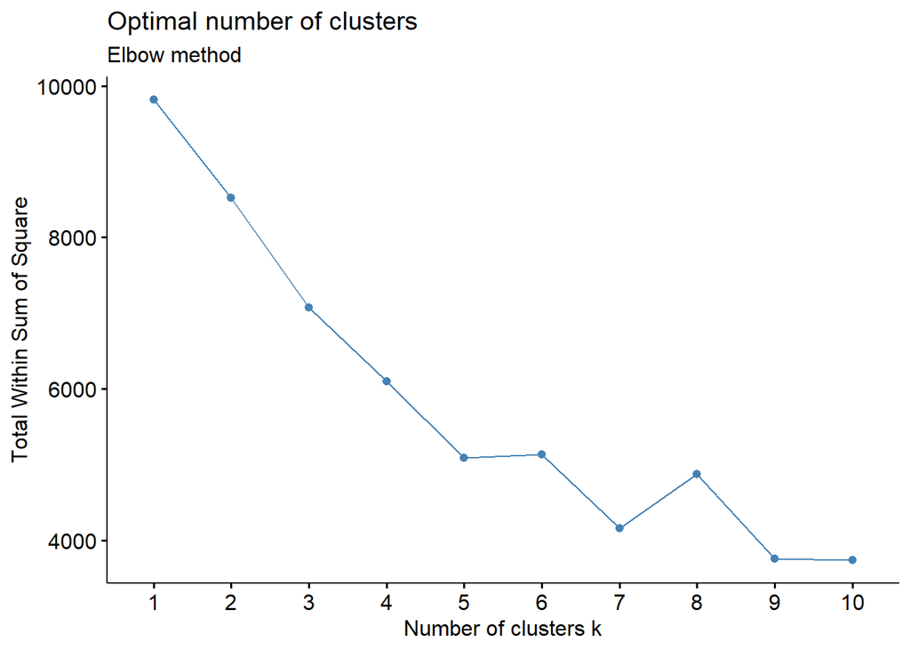

```r
fviz_nbclust(df_norm, kmeans, method = "wss") +
   labs(subtitle = "Elbow method")
```

from the Scree plot of the elbow method we can see that 5 or 6 is the optimal number of clusters

```r
km.out <- kmeans(df_norm, centers = 5, nstart = 20, iter.max = 50)
```

```r
# Viewing the cluster center datapoints by each attribute

km.out$centers
```

```
##   administrative administrative_duration informational informational_duration
## 1    0.092085908             0.025487412  0.0217833677           0.0147691213
## 2    0.001267057             0.000632593  0.0005482456           0.0003942661
## 3    0.096047035             0.026716283  0.0255730310           0.0170985746
## 4    0.126652969             0.036904214  0.0333985301           0.0229480327
## 5    0.077597341             0.021702142  0.0172542735           0.0107449937
##   productrelated productrelated_duration bouncerates  exitrates  pagevalues
## 1    0.051166488            0.0214217626  0.04966422 0.16323608 0.007088495
## 2    0.003557297            0.0006662914  0.90644845 0.94341110 0.000000000
## 3    0.049051347            0.0200198262  0.04725107 0.14870008 0.018250877
## 4    0.070190571            0.0302760969  0.02509143 0.09776657 0.075458373
## 5    0.037259502            0.0153393279  0.05768618 0.18339965 0.005291670
##   specialday     month operatingsystems   browser    region traffictype
## 1 0.00000000 0.8339054        0.1625268 0.1167010 0.2814798   0.1598303
## 2 0.10263158 0.4461988        0.1704887 0.1114035 0.2730263   0.2171745
## 3 0.05530358 0.5140616        0.1614589 0.1036028 0.2678767   0.1597428
## 4 0.02432432 0.5991781        0.1571835 0.1236368 0.2580903   0.1569215
## 5 0.12630769 0.2017094        0.1576923 0.1133974 0.2625641   0.1559919
##   visitortype   weekend     revenue
## 1  0.09017358 0.0000000 0.000000000
## 2  0.03421053 0.1605263 0.003947368
## 3  0.08833211 1.0000000 0.182516459
## 4  0.12339972 0.0000000 1.000000000
## 5  0.04615385 0.0000000 0.000000000
```

```r
# Looking at how many data points are in each cluster
km.out$size
```

```
## [1] 3399  760 2734 1406 3900
```

```r
# Set up 2 x 3 plotting grid
par(mfrow = c(2, 3))

# Set seed
set.seed(23)

for(i in 5:10) {
  # Run kmeans() on df_norm with i clusters
  km.out <- kmeans(df_norm, centers = i, nstart = 20)

  # Plot clusters
  #plot(df_norm, col = km.out$cluster,
  #     main = km.out$tot.withinss,
  #     xlab = "x", ylab = "y")
  }
```

# Haerachial clustering.

```r
# Making the clustering model
hclust.out <- hclust (dist(df_norm), method = "complete")
summary(hclust.out)
```

```
##             Length Class  Mode
## merge       24396  -none- numeric
## height      12198  -none- numeric
## order       12199  -none- numeric
## labels      12199  -none- character
## method          1  -none- character
## call            3  -none- call
## dist.method     1  -none- character
```

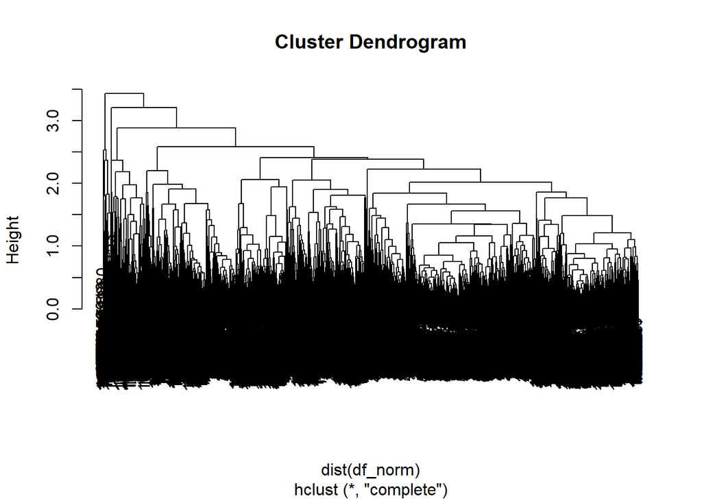

```r
# Drawing the output of the Hierachial cluster
plot (hclust.out)
```

As we can see this is a very big mess. Therefore, the number of clusters can be used as a metric to cut down the tree.

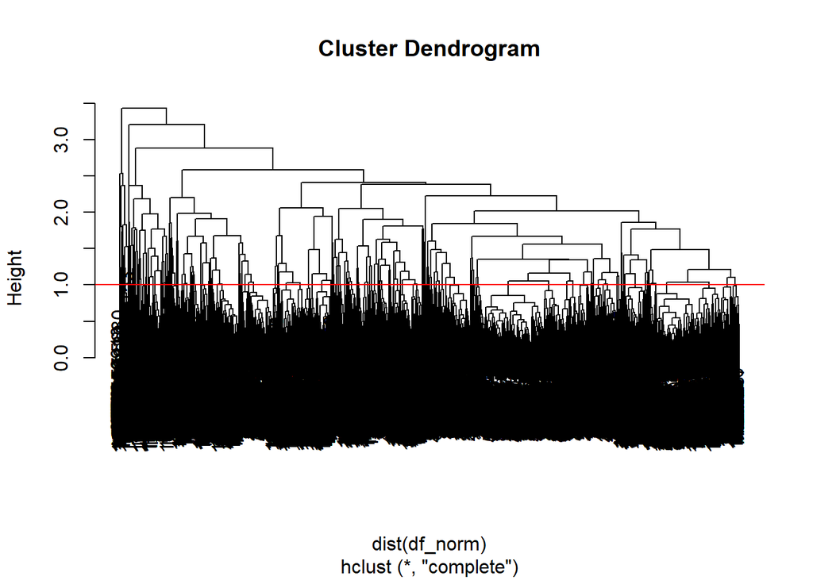

```r
# Drawing the cut off point on the tree

plot (hclust.out)
abline (h=1 , col = "red")
```

Now we have to cut the tree using the predetermined optimal cluster number

```r
# cut the tree
cut.df <- cutree(hclust.out, k = 6)
```

```r
# Compare methods
table(km.out$cluster, cut.df)
```

```
##     cut.df
##         1    2    3    4    5    6
##   1    10  876    0    4    0    0
##   2   661   73    1    0    0    5
##   3    32 2990    0    0    0    0
##   4     0  476   22    1    0    0
##   5    17 2560    0    2    2    0
##   6    28    0 1114    0    1    0
##   7     0  503    0    0    0    0
##   8     0  858    0   45    0    0
##   9    14  694    0  118    0    0
##   10   29  139  923    1    0    0
```

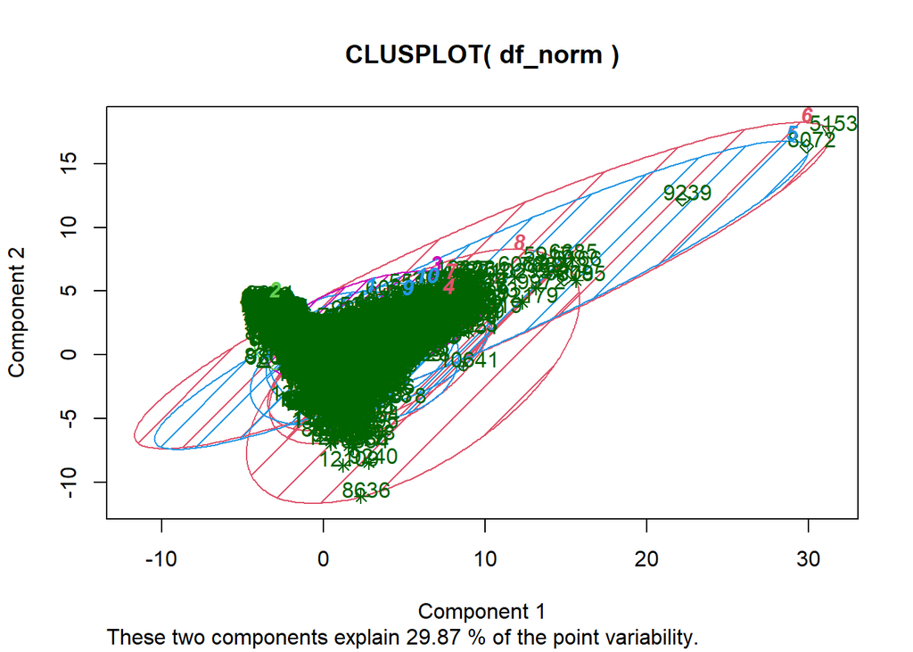

```r
library(cluster)
clusplot(df_norm, km.out$cluster, color=TRUE, shade=TRUE,
    labels=2, lines=0)
```

# Follow up Questions Was the data provided enough to answer the question? Yes, the data was sufficient.

What could be done to improve the quality of data? The data had many columns. However, applying dimension reduction techniques to the data would make it more understandable and easy to work with.